# Analysis of Diff-in-Diff Data - Carrefour Rome

Published

December 10, 2024

# Instructions

Please submit your assignment as html file to me via email. Please call your assignment: “yourname_assignment5.html”. For example, I would submit something called “popescu_assignment5.html”. Please make sure that it is all in lower case.

To match the appearance of this template, ensure that your assignment preamble or YAML is set up as follows

```
---
title: "Assignment 5"
author: "Your Name"
date: "December 10, 2024"
format:
  html:
    toc: true
    number-sections: true
    colorlinks: true
    smooth-scroll: true
    embed-resources: true
---
```

Important: Headers like “Question” should be marked with a `#` (for example, `# Question`). This will format the text as a bold, larger header when the document is rendered, and it will also appear in the Table of Contents. For regular text, simply write it on the line below the header.

Please answer all the questions below.

# 1 Introduction

In this hypothetical situation (the data is made up, i.e. does not exist), Carrefour Rome is evaluating the effectiveness of a coupon program designed to increase revenue by providing discount coupons for purchases over 40 euros. So they chose all the Carrefour Ipers and provided coupons from August until December.

# 2 Loading the Data

You can download the data from:

- [Diff-in-Diff Data](https://www.dropbox.com/s/cqsawoo10wmp4wl/did_data_geo_carrefour.csv?dl=0)
- Spatial Data on [roads](https://www.dropbox.com/sh/pj5u635nrutn9m6/AABpHtbgRhzIhmkXgiqhidqQa?dl=0) from the Rome Area

So, we want to calculate $\beta_3$ from:

$$[Y_{it} = \beta_0 + \beta_1 \text{Group}_i + \beta_2 \text{Time}_t +\beta_3 (\text{Group}_i \times \text{Time}_t) + \epsilon_{it}$$

# Question 1

Write the relevant equation for the problem and explain what the different terms represent.

The equation for for the problem can be written as:

$$\text{Revenue}_{it} = \beta_0 + \beta_1 \text{Carrefour Iper}_i + \beta_2 \text{Post-August}_t +\beta_3 (\text{Carrefour Iper}_i \times \text{Post-August}_t) + \epsilon_{it}$$
where:

Carrefour Iper = 1 if this is the Carrefour Iper group or the treatment group  
Time = 1 if this is the period after intervention, after August  
$\beta_0$ - mean of the control group (other Carrefour store that are not Iper) in the pre-treatment period (before August)  
$\beta_1$ - the increase in revenue across groups  
$\beta_2$ - the increase in outcome within groups.  
$\beta_3$ - the differences in differences

# Question 2

Create a DAG that maps out the variables that we care about.

```r
dag <- dagify(revenue ~ coupon + month + carrefour_iper,
                     coupon ~ month + carrefour_iper,
                     exposure = "coupon",
                     outcome = "revenue",
                     labels = c(revenue = "Revenue",
                                coupon = "Coupon",
                                month = "month",
                                carrefour_iper = "carrefour_iper"),
                     coords = list(x = c(revenue = 3, coupon = 1, month = 2, carrefour_iper = 2),
                                   y = c(revenue = 2, coupon = 2, month = 3, carrefour_iper = 1)))

bigger_dag <-data.frame(tidy_dagitty(dag))
bigger_dag$type<-NA
#bigger_dag$type<-"Confounder"
bigger_dag$type<-""
bigger_dag$type[bigger_dag$name=="revenue"]<-"Outcome"
bigger_dag$type[bigger_dag$name=="coupon"]<-"Intervention"
min_lon_x<-min(bigger_dag$x)
max_lon_x<-max(bigger_dag$x)
min_lat_y<-min(bigger_dag$y)
max_lat_y<-max(bigger_dag$y)
```

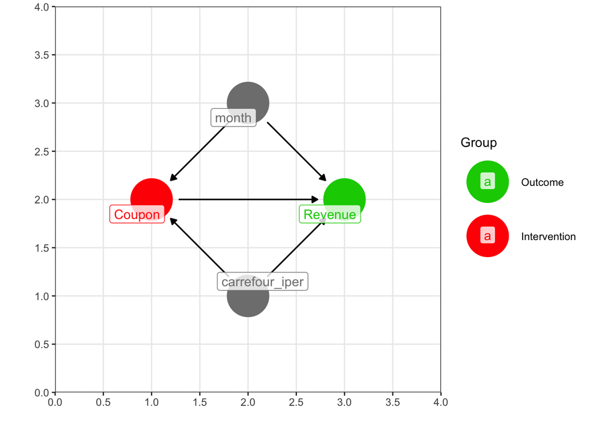

```r
col = c("Outcome"="green3",
        "Intervention"="red",
        "Confounder"="grey60")

order_col<-c("Outcome", "Intervention", "Confounder")


example_dag<-ggplot(data = bigger_dag, aes(x = x, y = y, xend = xend, yend = yend, color=type)) +
  geom_dag_point() +
  geom_dag_edges() +
  coord_sf(xlim = c(min_lon_x-1, max_lon_x+1), ylim = c(min_lat_y-1, max_lat_y+1), expand = FALSE)+
    scale_colour_manual(values = col,
                      name = "Group",
                      breaks = order_col)+
        geom_label_repel(data = subset(bigger_dag, !duplicated(bigger_dag$label)),
                   aes(label = label), fill = alpha(c("white"),0.8))+

    theme_bw()+
  labs(x = "", y="")
ggsave(example_dag, file = "./graphs/example_dag1.jpg",
       height = 20, width = 25,
       units = "cm", dpi = 200)

example_dag
```

# Question 3

Create a static map for the area of interest and depict the different types of Carrerfour in different colors.

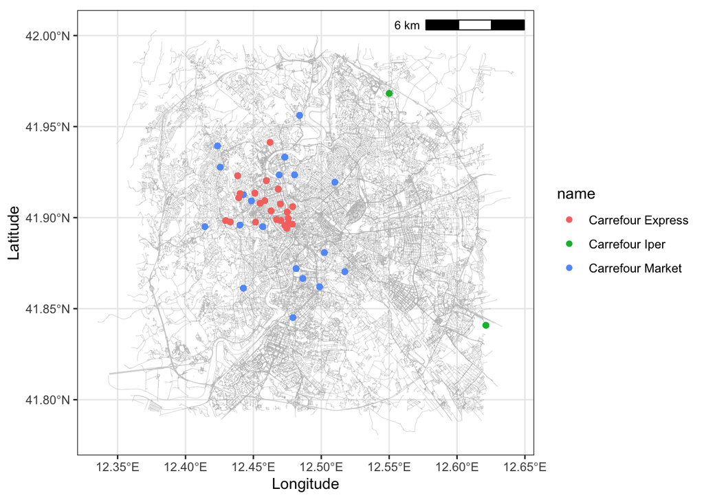

# Question 4

Create a summary statistics table for the data and comment on the skewness or normality of the following variables: variety of products, store size, traffic, and revenue.

Unique

Missing Pct.

Mean

SD

Min

Median

Max

Histogram

variety_products

528

0

70.6

15.9

40.6

71.6

103.8

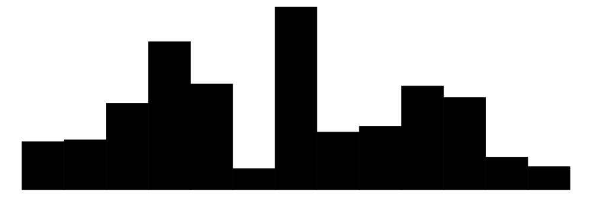

store_size

44

0

349.3

256.1

43.0

290.5

1071.0

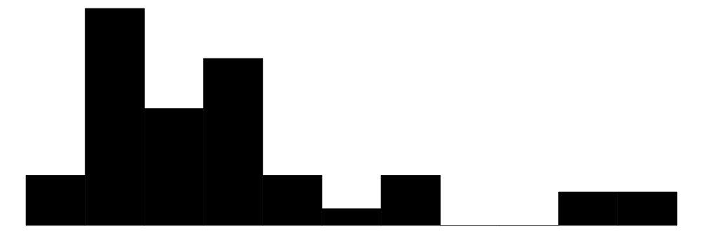

traffic

528

0

1559.6

1227.5

34.1

1327.2

5935.6

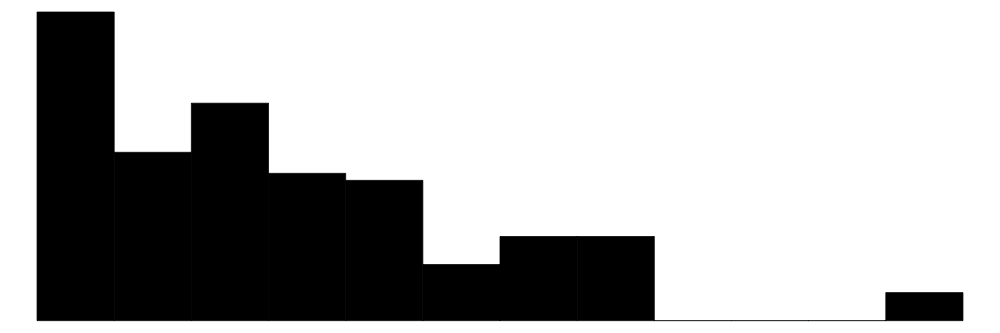

revenue

528

0

102966.8

2087.8

98633.9

102773.9

111391.5

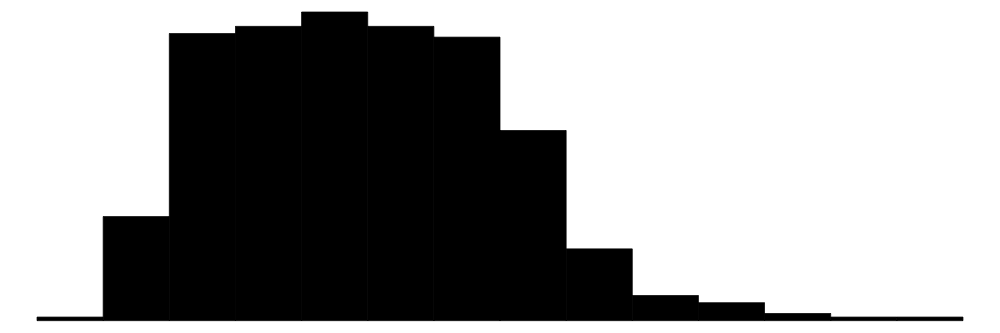

id

44

0

22.5

12.7

1.0

22.5

44.0

[figure not shown]

lat_y

44

0

41.9

0.0

41.8

41.9

42.0

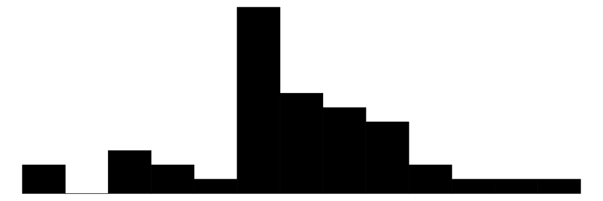

lon_x

44

0

12.5

0.0

12.4

12.5

12.6

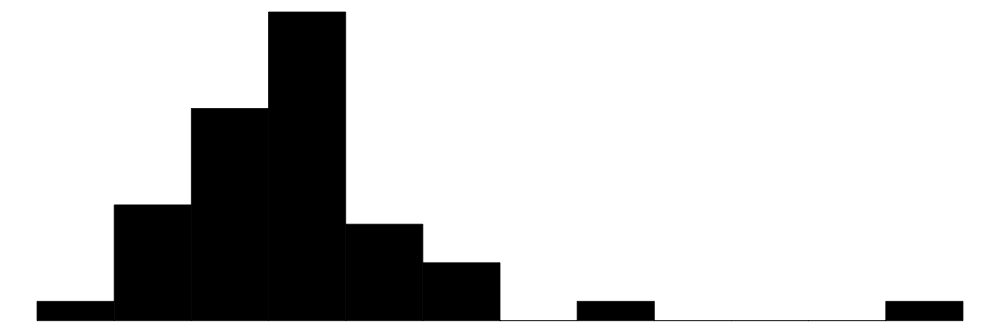

after

2

0

0.4

0.5

0.0

0.0

1.0

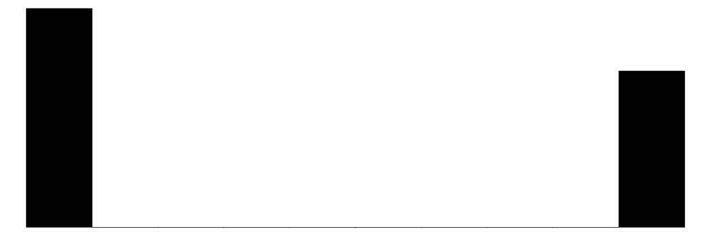

treatment

2

0

0.0

0.2

0.0

0.0

1.0

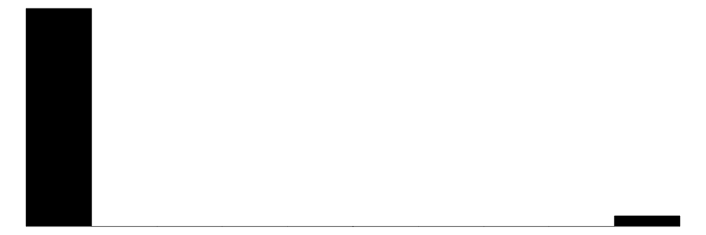

month

12

0

6.5

3.5

1.0

6.5

12.0

[figure not shown]

N

%

name

Carrefour Express

276

52.3

Carrefour Iper

24

4.5

Carrefour Market

228

43.2

address

CIRCONVALLAZIONE TRIONFALE,112 - ROMA (RM)

12

2.3

CORSO VITTORIO EMANUELE II, 286-288-290 - ROMA (RM)

12

2.3

LARGO LORIA N. 6 - ROMA (RM)

12

2.3

LARGO LUCIO APULEIO 10 - ROMA (RM)

12

2.3

P.LE DEGLI EROI - ROMA (RM)

12

2.3

P.LE MORELLI N. 52 - ROMA (RM)

12

2.3

PIAZZA BENEDETTO CAIROLI 13 - ROMA (RM)

12

2.3

PIAZZA IRNERIO 51/52 - ROMA (RM)

12

2.3

PIAZZA NICOSIA,35 - ROMA (RM)

12

2.3

V.LE GERMANIA - ROMA (RM)

12

2.3

VIA AJACCIO N.29-31-35-37-39 - ROMA (RM)

12

2.3

VIA ALESIA 35/37 - ROMA (RM)

12

2.3

VIA APPIANO 31 - ROMA (RM)

12

2.3

VIA AURELIA 350 - ROMA (RM)

12

2.3

VIA BUFALOTTA - ROMA (RM)

12

2.3

VIA CESARE BARONIO N. 161/165 - ROMA (RM)

12

2.3

VIA CESARE FRACASSINI 62 - ROMA (RM)

12

2.3

VIA DEL BISCIONE 79 - ROMA (RM)

12

2.3

VIA DEL GESU', 57-58-59 - ROMA (RM)

12

2.3

VIA DEL GOVERNO VECCHIO 119 - ROMA (RM)

12

2.3

VIA DELL'ACQUEDOTTO DEL PESCHIERA DAL N.22 AL 30/A - ROMA (RM)

12

2.3

VIA DELLA BALDUINA 217 - ROMA (RM)

12

2.3

VIA DELLA CROCE 48 - ROMA (RM)

12

2.3

VIA DELLA PINETA SACCHETTI, 199 - ROMA (RM)

12

2.3

VIA DELLE FORNACI DAL N. 136 AL N. 154 - ROMA (RM)

12

2.3

VIA DI PORTA CASTELLO 10 - ROMA (RM)

12

2.3

VIA E.DONATO N.27 - ROMA (RM)

12

2.3

VIA FLAMINIA KM. 8,200 - ROMA (RM)

12

2.3

VIA GIACOMO BOVE, 4, 4/A, 4/C, 4/D, 4E, 16 - ROMA (RM)

12

2.3

VIA GIOVANNI NICOTERA 13/27 - ROMA (RM)

12

2.3

VIA GIUSTINIANI 15B - ROMA (RM)

12

2.3

VIA GREGORIO VII - ROMA (RM)

12

2.3

VIA GREGORIO XI N.201/209 - ROMA (RM)

12

2.3

VIA IGNAZIO PERSICO N.82 - ROMA (RM)

12

2.3

VIA L.SCHIAVONETTI N.420-426-432 - ROMA (RM)

12

2.3

VIA LAURENTINA 84 - ROMA (RM)

12

2.3

VIA LUCREZIO CARO,43 - ROMA (RM)

12

2.3

VIA MONTE DEL GALLO 9-13B - ROMA (RM)

12

2.3

VIA MONTE PERTICA,27 - ROMA (RM)

12

2.3

VIA MONTERONE,8 - ROMA (RM)

12

2.3

VIA MONTICELLI N. 9/21 - ROMA (RM)

12

2.3

VIA ORTI DELLA FARNESINA, 83-85-87- - ROMA (RM)

12

2.3

VIA SEBASTIANO VENIERO, 10/A-12-14-16 - ROMA (RM)

12

2.3

VIALE GIULIO CESARE 143 - ROMA (RM)

12

2.3

```r
datasummary_skim(carrefour)
```

Variety of products is approximately normally distributed. Store size and traffic are right-skewed. Revenue is approximately normally distributed.

# Question 5

What is the number of stores where the coupon program got implemented?

```r
treat_no<-subset(carrefour, !duplicated(id))
treat_no2<-subset(treat_no, treatment==1)
nrow(treat_no2)
```

```
[1] 2
```

# Question 6

What is the duration of the coupon program?

```r
treat_no3<-subset(carrefour, after==1)
max(treat_no3$month)-min(treat_no3$month)
```

```
[1] 4
```

# Question 7

Calculate $\beta_3 (\text{Group}_i \times \text{Time}_t)$ from:

$$Y_{it} = \beta_0 + \beta_1 \text{Group}_i + \beta_2 \text{Time}_t + \beta_3 (\text{Group}_i \times \text{Time}_t) + \epsilon_{it}$$

```r
model_did <- lm(revenue ~ treatment + after + treatment * after, data = carrefour)
options(modelsummary_format_numeric_latex = "plain")
modelsummary(model_did, stars = TRUE,  gof_map = c("nobs", "r.squared"))
```

|  | (1) |
| --- | --- |
| (Intercept) | 101637.248*** |
|  | (71.847) |
| treatment | -475.018 |
|  | (336.992) |
| after | 3041.381*** |
|  | (111.305) |
| treatment × after | 4431.434*** |
|  | (522.067) |
| Num.Obs. | 528 |
| R2 | 0.654 |

+ p < 0.1, * p < 0.05, ** p < 0.01, *** p < 0.001

# Question 8

Interpret the coefficients from the table.

Being in the treatment group (Carrefour Iper) is associated with a 475 euro decrease on average; being in the group after August is associated with a 3041.38 euro increase on average, and being in treatment group (Carrefour Iper) after August causes an increase in revenue of 4431.43 euros.

# Question 9

Create an event-study plot.

```r
plot_data <- carrefour %>%
  group_by(month, treatment) %>%
  summarize(mean_revenue = mean(revenue),
            se_revenue = sd(revenue) / sqrt(n()),
            upper = mean_revenue + (1.96 * se_revenue),
            lower = mean_revenue + (-1.96 * se_revenue))
plot_data$group<-NA
plot_data$group[plot_data$treatment==1]<-"Treatment"
plot_data$group[plot_data$treatment==0]<-"Control"
```

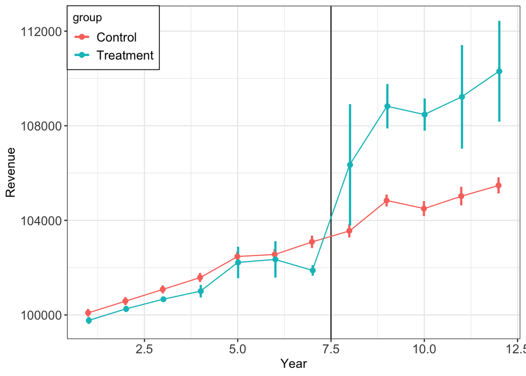

```r
mean_revenue<-ggplot(plot_data, aes(x = month, y = mean_revenue, color=group)) +
  geom_vline(xintercept = 7.5) +
    geom_errorbar(aes(ymin = lower, ymax = upper),
                size = 1, width = 0,
                position=position_dodge(width=0.04))+
      geom_point(size = 2,
             position=position_dodge(width=0.04))+
   geom_line()+
  theme(legend.position = "bottom")+
    labs(x = "Year", y = "Revenue")+
  theme_bw() +
  theme(axis.text.x = element_text(size=12),
        axis.text.x.top  = element_text(size=10, angle = 45, margin=margin(5,5,10,5,"pt")),
        axis.text.y = element_text(size=12),
        axis.title=element_text(size=12),
        plot.title = element_text(hjust = 0.5),
        legend.position = c(1, 0),
        #Legend.position values should be between 0 and 1. c(0,0) corresponds to the "bottom left"
        #and c(1,1) corresponds to the "top right" position.
        legend.box.background = element_rect(fill='white'),
        legend.background = element_blank(),
        legend.text=element_text(size=12))
mean_revenue<-reposition_legend(mean_revenue, 'top left')
```

```r
ggsave(mean_revenue, file = "./graphs/fig_dif_dif.jpg",
       height = 12, width = 20,
       units = "cm", dpi = 200)
```

# Question 10

Does the parallel trends assumption hold?

Yes. The revenue for Carrefour Iper and other stores are very similar. After the intervention in August (coupon program), revenues for Carrefour Iper increases substantially.

# Question 11

What do you tell the Carrefour manager? Do the coupons work? Should Carrefour expand the coupon system?

Yes, the coupon system works. Offering the coupon system increased Carrerfour revenue by 4431.434 euros. It might be worth expanding the coupon system to larger areas.